# numpy的相关知识

## 删除某一个特征的所有数据

```python
a = [1,2,3]
b1=a[0]
b2 = a[-1]
a.insert(0,a[0])
a.insert(-1,a[-1])
"""----------------------------------------------------------------------"""

# 删除某一个特征的所有数据

# pandas 删除全是女生的行

import pandas as pd
df = pd.DataFrame({"key":['green','red', 'blue'],
            "data1":['a','b','c'],"sorce": [33,61,99]})
print(df)
print("---------------")

data1 = pd.concat([df,df],ignore_index=True)

data2=data1[-data1.sorce.isin([61])]


"""----------------------------------------------------------------------"""
```

## 导入的包

```python
import datetime
import numpy as np
import pandas as pd
from geopy.distance import geodesic
from collections import defaultdict,OrderedDict
import matplotlib.pyplot as plt
import dateutil
import warnings

warnings.filterwarnings('ignore')
# %matplotlib inline

# 这个是mac的画图中文乱码，window的可能不太一样
# 画图中文错误
# 用来正常显示中文标签
# window的画图中文乱码
# plt.rcParams['font.sans-serif'] = ['SimHei'] # 指定默认字体
# plt.rcParams['axes.unicode_minus'] = False # 解决保存图像是负号'-'显示为方块的问题

plt.rcParams['font.sans-serif'] = ['Arial Unicode Ms']
# 用来正常显示负号
plt.rcParams['axes.unicode_minus'] = False
# 可视化矩阵

# ————————————————————————————————————————————————————————————————————————————————————————————
```

## list_dict_Series

```python
"""
python 数据类型list、dict、numpy array、series、dataframe之间的转换\

https://blog.csdn.net/rosefun96/article/details/78970239


"""
"""---------------------------------------------------------------------------------------"""

#  1. list to others

import numpy as np
import pandas as pd
from pandas import Series, DataFrame


# list
data = [[2000, 'Ohino', 1.5],
        [2001, 'Ohino', 1.7],
        [2002, 'Ohino', 3.6],
        [2001, 'Nevada', 2.4],
        [2002, 'Nevada', 2.9]]  # type(data) 为 list

# list to series
ser = Series(data, index = ['one', 'two', 'three', 'four', 'five'])

# list to dataframe
df = DataFrame(data, index = ['one', 'two', 'three', 'four', 'five'], columns = ['year', 'state', 'pop'])

# list to array
ndarray = np.array(data)

"""---------------------------------------------------------------------------------"""

# 2. ndarray to others

# array to dataframe
pd = DataFrame(ndarray, index = ['one', 'two', 'three', 'four',
'five'],
columns = ['year', 'state', 'pop'])

# ndarray to list
mylist = ndarray.tolist()

"""---------------------------------------------------------------------------------------"""

# 3. dict to others

import numpy as np
import pandas as pd
from pandas import Series, DataFrame

# dict
data = { 'name': ['Li', 'Zhang', 'Wang'],
         'year': [2000, 2001, 2002]}  # type(data) 为 dict

# dict to series
# 若不指定 index，data 的 key 充当 Series 的 index
ser = Series(data)
print('ser\n', ser)

# dict to dataframe
# 若不指定 columns，data 的 key 充当 DataFrame 的 columns
df = DataFrame(data)
print('df\n', df)

"""---------------------------------------------------------------------------------------"""

# 4. Series to others

# 如果把DataFrame取一列就是Series格式了。

# series to np array

# 需要pandas version 0.24以上
arr = ser.to_numpy()
# 或者
arr = np.array(ser)
# Series转换成dict
dt = ser.to_dict()

"""---------------------------------------------------------------------------------------"""

# 5. DataFrame to others
# dataframe
data = DataFrame(np.array([[1, 2, 3], [4, 5, 6], [7, 8, 9]]), columns=['a', 'b', 'c'])
print(data)

# dataframe to array
arr = data.values
print('arr\n', arr)
print(type(arr))

# dataframe to dict
dict = data.to_dict()
print(dict)

"""
#  DataFrame.to_dict(self, orient='dict', into=<class 'dict'>) 还可以转换成 list,series等：

 orient : str {‘dict’, ‘list’, ‘series’, ‘split’, ‘records’, ‘index’}
Determines the type of the values of the dictionary.

‘dict’ (default) : dict like {column -> {index -> value}}
‘list’ : dict like {column -> [values]}
‘series’ : dict like {column -> Series(values)}
‘split’ : dict like {‘index’ -> [index], ‘columns’ -> [columns], ‘data’ -> [values]}
‘records’ : list like [{column -> value}, … , {column -> value}]
‘index’ : dict like {index -> {column -> value}}
Abbreviations are allowed. s indicates series and sp indicates split.

"""

"""---------------------------------------------------------------------------------------"""
```

## merge数据合并

```python
# merge数据合并
"""
https://zhuanlan.zhihu.com/p/102274476

上面的引入部分说到merge是用来拼接两张表的，那么拼接时自然就需要将用户信息一一对应地进行拼接，
所以进行拼接的两张表需要有一个共同的识别用户的键（key）。总结来说，整个merge的过程就是将信息
一一对应匹配的过程，下面介绍merge的四种类型，分别为'inner'、'left'、'right'和'outer'。

一、inner
merge的'inner'的类型称为内连接，它在拼接的过程中会取两张表的键（key）的交集进行拼接。

二、left 和right
'left'和'right'的merge方式其实是类似的，分别被称为左连接和右连接。这两种方法是可以互相转换的，所以在这里放在一起介绍。

'left'
merge时，以左边表格的键为基准进行配对，如果左边表格中的键在右边不存在，则用缺失值NaN填充。


'right'
merge时，以右边表格的键为基准进行配对，如果右边表格中的键在左边不存在，则用缺失值NaN填充。

三、outer

'outer'是外连接，在拼接的过程中它会取两张表的键（key）的并集进行拼接


"""

# 1.现在用'inner'的方式进行merge

df_1 = pd.DataFrame({'age':[23, 46, 32, 19], 'useid':['a','b','c','d']})
df_2 = pd.DataFrame({'payment':[2000, 3500], "useid":['a','b']})

df_1.merge(df_2,how='inner',on='useid')  # 你有我有的useid, 交集


# 2. left
df_1.merge(df_2,how='left',on='useid')  # 左边有的id 右边没有， 则 右边的补NAN  ②若右表中的payment列合并到左表中，对于没有匹配值的用缺失值NaN填充

#3.right

df_2.merge(df_1,how='right',on='useid')
                  # 对于'right'类型的merge和'left'其实是差不多的，只要把两个表格的位置调换一下，两种方式返回的结果就是一样的（），如下：

# 4. outer


df_1 = pd.DataFrame({'age':[23, 46, 32, 19], 'useid':['a','b','c','d']})
df_2 = pd.DataFrame({'payment':[2000, 3500, 3000], "useid":['a','b','e']})

df_1.merge(df_2,how='outer',on='useid')


#  对于我们的原始数据，首先将车辆基础数据进行预处理留下合理数据， 将GPS基础数据与车辆基础数据进行拼接，使用”inner“,拼接就可以了
```

## groupby

```python
# Pandas数据处理三板斧——map、apply、applymap详解

boolean=[True,False]
gender=["男","女"]
color=["white","black","yellow"]
data_d1=pd.DataFrame({
    "height":np.random.randint(150,190,100),
    "weight":np.random.randint(40,90,100),
    "smoker":[boolean[x] for x in np.random.randint(0,2,100)],
    "gender":[gender[x] for x in np.random.randint(0,2,100)],
    "age":np.random.randint(15,90,100),
    "color":[color[x] for x in np.random.randint(0,len(color),100) ]
}
)

"""
1. map用法
如果需要把数据集中gender列的男替换为1，女替换为0，怎么做呢？绝对不是用for循环实现，
使用Series.map()可以很容易做到，最少仅需一行代码。
"""
# ①使用字典进行映射
data_d1['gender'] = data_d1['gender'].map({"男":1, "女": 0})

#②使用函数
def gender_map(x):
    gender = 1 if x == "男" else 0
    return gender
#注意这里传入的是函数名，不带括号
data["gender"] = data["gender"].map(gender_map)

"""
不论是利用字典还是函数进行映射，map方法都是把对应的数据逐个当作参数传入到字典或函数中，得到映射后的值。
"""

"""-----------------------------------------------------------------------------------------------"""

# 2. apply,

# https://zhuanlan.zhihu.com/p/100064394

def apply_age(x,bias):
    return x+bias

#以元组的方式传入额外的参数

data["age"] = data["age"].apply(apply_age,args=(-3,))  #  可以看到age列都减了3

# 总而言之，对于Series而言，map可以解决绝大多数的数据处理需求，但如果需要使用较为复杂的函数，则需要用到apply方法。

# 沿着0轴求和
data[["height","weight","age"]].apply(np.sum, axis=0)  # 列和

# 沿着0轴取对数
data[["height","weight","age"]].apply(np.log, axis=0)  # 列和


# 行和

def BMI(series):
    weight = series["weight"]
    height = series["height"]/100
    BMI = weight/height**2
    return BMI

data["BMI"] = data.apply(BMI,axis=1)

"""-----------------------------------------------------------------------------------------------"""

# 3. applymap

data_df = pd.DataFrame(
    {
        "A":np.random.randn(5),
        "B":np.random.randn(5),
        "C":np.random.randn(5),
        "D":np.random.randn(5),
        "E":np.random.randn(5),
    }
)

# 将DataFrame中所有的值保留两位小数显示

data_df.applymap(lambda x:"%.2f" % x)




day = [data_lo.time.iloc[i].date().strftime('%Y-%m-%d') for i in range(len(data_lo))]  # 把time 转换有y_m_d的字符串类型

data_lo['day'] = day  # 把 day 加入到 data_lo数据集

data_lo.to_csv('data_location_del_less_10.csv', index=None)  # 保存数据

d1 = data_lo.groupby("ID")["day"].value_counts()  # 按ID对数据进行分组，在每个ID中按day统计个数， 知道每个ID下一共有多少天的数据，每天的数据量是多少

d1.to_csv('day_counts_point.csv')  # 保存id下每天的记录

d1 = pd.read_csv('day_counts_point.csv', index_col=None)  # 读取数据

d2 = d1.groupby("ID")["count"].agg(['max','min','mean','count','sum', 'median','std','var'])  # 使用 agg将多个函数功能合并展示

#  https://zhuanlan.zhihu.com/p/101284491?utm_source=wechat_session

# pandas 分组操作groupby, agg, transform,

#  实现分组操作的代码很简单，
company=["A","B","C"]
cd = ['D', 'E','F']
df = pd.DataFrame({
    "company":[company[x] for x in np.random.randint(0,len(company),10)],
    'cd':[cd[x] for x in np.random.randint(0,len(company),10)],
    "salary":np.random.randint(5,50,10),
    "age":np.random.randint(15,50,10)
}
)


group = df.groupby('company')  # 将上面的数据集按照company字段进行划分

list(group)  # 这里把group转换成list的形式

# 如果想对针对不同的列求不同的值，比如要计算不同公司员工的平均年龄以及薪水的中位数，可以利用字典指定进行聚合操作：

df.groupby('company').agg({'salary':'median','age':'mean'})

"""
在上面的agg中，我们学会了如何求不同公司员工的平均薪水，如果现在需要在原数据集中新增一列avg_salary，
代表员工所在的公司的平均薪水（相同公司的员工具有一样的平均薪水），该怎么实现呢？如果按照正常的步骤来
计算，需要先求得不同公司的平均薪水，然后按照员工和公司的对应关系填充到对应的位置，不用transform的话，
实现代码如下：
"""
# https://blog.csdn.net/weixin_42028854/article/details/88829352?utm_medium=distribute.pc_relevant.none-task-blog-BlogCommendFromMachineLearnPai2-2.channel_param&depth_1-utm_source=distribute.pc_relevant.none-task-blog-BlogCommendFromMachineLearnPai2-2.channel_param

# pandas 转换为字典， orient:value的形式：“list”, "dist", "series", "split", "report", "index"

# df.to_dict(orient="list")

avg_salary_dict = df.groupby("company")['salary'].mean().to_dict()

df['avg_salary'] = df['company'].map(avg_salary_dict)  # 对company的列进行操作

# 可以直接用transform实现avg_salary_dict， 和map的功能

df['avg_salary1'] = df.groupby('company')['salary'].transform('mean')
```

# matplotlib

```
[10.67505325  0.13679816]
a: 10.675053250404702
b: 0.13679815966601344
0 : x(i): -3 fit Y: 6.981502939422338
1 : x(i): -2 fit Y: 9.580667973076594
2 : x(i): -1 fit Y: 10.538255090738689
3 : x(i): 2 fit Y: 11.76943852773281
4 : x(i): 4 fit Y: 19.430135469029562
```

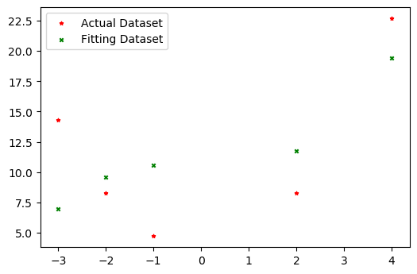

```python
import numpy as np
import matplotlib.pyplot as plt  # Python 绘图工具(业界推荐)

# 数据初始化
A = [
    [1,pow(-3,3)],
    [1,pow(-2,3)],
    [1,pow(-1,3)],
    [1,pow(2,3)],
    [1,pow(4,3)]
];

At =  np.transpose(A); # A的转置矩阵

y = np.transpose([14.3,8.3,4.7,8.3,22.7]);


# step1:求解
## 令 (a ,b)^T 为 未知参数X
X = np.dot(np.dot(np.linalg.inv(np.dot(At,A)),At),y)
print(X)
print("a:",X[0])
print("b:",X[1])

# step2:查看拟合效果
x = [-3,-2,-1,2,4];
## 1. 计算拟合数值 fitValue
def fitValue(arg_x):
    a = X[0];
    b = X[1];
    return a + b*pow(arg_x,3);

fitValues = np.zeros([5]); # 创建长为5的【一维】数组；[1,5]：创建第1行为5个元素的【二维】数组
for i in range(0,len(fitValues)):
    fitValues[i] = fitValue(x[i]);
    print(i,":","x(i):",x[i],"fit Y:",fitValues[i]); # just for test
    pass;

## 2. 绘图可视化
yt = np.transpose(y); # y的转置
plt.rcParams['figure.dpi'] = 100 #分辨率
plt.scatter(x, yt, marker = '*',color = 'red', s = 10 ,label = 'Actual Dataset') # 真实数据集
plt.scatter(x, fitValues, marker = 'x',color = 'green', s = 10 ,label = 'Fitting Dataset') #[拟合数据集]
plt.legend(loc = 'best')    # 设置 图例所在的位置 使用推荐位置
plt.show()
```

## matplotlib 画子图

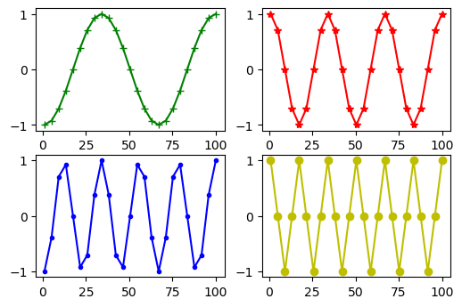

```python
from matplotlib import pyplot as plt
import numpy as np
x = np.linspace(1, 100, num= 25, endpoint = True)
def y_subplot(x,i):
    return np.cos(i * np.pi *x)
#使用subplots 画图
f, ax = plt.subplots(2,2)
#type(f) #matplotlib.figure.Figure

style_list = ["g+-", "r*-", "b.-", "yo-"]
ax[0][0].plot(x, y_subplot(x, 1), style_list[0])
ax[0][1].plot(x, y_subplot(x, 2), style_list[1])
ax[1][0].plot(x, y_subplot(x, 3), style_list[2])
ax[1][1].plot(x, y_subplot(x, 4), style_list[3])

plt.show()
```

```python
2. #使用subplot画图
for i in  range(1,5):
    plt.subplot(2,2,i)
    plt.plot(x, y_subplot(x,i), style_list[i- 1])
plt.show()
```

## 画图基础操作

```python
# 图名，图例，轴标签，轴边界，轴刻度，轴刻度标签等

df = pd.DataFrame(np.random.rand(10,2),columns=['A','B'])
fig = df.plot(figsize=(12, 6))
# figsize：创建图表窗口，设置窗口大小
# 创建图表对象，并赋值与fig

plt.title('Interesting Graph - Check it out')  # 图名
plt.xlabel('Plot Number')  # x轴标签
plt.ylabel('Important var') # y轴标签

plt.legend(loc = 'upper right')
# 显示图例，loc表示位置
# 'best'         : 0, (only implemented for axes legends)(自适应方式)
# 'upper right'  : 1,
# 'upper left'   : 2,
# 'lower left'   : 3,
# 'lower right'  : 4,
# 'right'        : 5,
# 'center left'  : 6,
# 'center right' : 7,
# 'lower center' : 8,
# 'upper center' : 9,
# 'center'       : 10,

plt.xlim([0,12])  # x轴边界
plt.ylim([0,1.5])  # y轴边界
plt.xticks(range(10))  # 设置x刻度
plt.yticks([0,0.2,0.4,0.6,0.8,1.0,1.2])  # 设置y刻度
fig.set_xticklabels("%.1f" %i for i in range(10))  # x轴刻度标签 保留小数点后一位小数
fig.set_yticklabels("%.2f" %i for i in [0,0.2,0.4,0.6,0.8,1.0,1.2])  # y轴刻度标签 #保留小数点后2位小数
 # 范围只限定图表的长度，刻度则是决定显示的标尺 → 这里x轴范围是0-12，但刻度只是0-9，刻度标签使得其显示1位小数 # 轴标签则是显示刻度的标签 print(fig,type(fig)) # 查看表格本身的显示方式，以及类别
"""------------------------------------------------------------------------------------------------------------------------------------------------------------------------"""

# 2. 散点图

# 对于 id的个数画图，查看一下，id的数量分布
fig = plt.figure(figsize=(12, 8))

#新加入的代码如下：
# plt.xlabel("") #x轴说明
# plt.ylabel("id的计数") #y轴说明
plt.title("车辆的经纬度") #此图像的标题
plt.scatter(data_37532_1_03_del_33['gpsX'], data_37532_1_03_del_33['gpsY'])
plt.scatter(data_37532_1_03_del['gpsX'], data_37532_1_03_del['gpsY'], marker='*', color = 'red')
plt.show()

"""------------------------------------------------------------------------------------------------------------------------------------------------------------------------"""


# 3.

# 对于 id的个数画图，查看一下，id的数量分布
fig = plt.figure(figsize=(12, 8))
data_37532_1_03_del_second = data_37532_1_03_del_33.loc[v_del[v_del[0] > 33.33].index]
#新加入的代码如下：
# plt.xlabel("") #x轴说明
# plt.ylabel("id的计数") #y轴说明
plt.title("车辆的经纬度") #此图像的标题
plt.scatter(data_37532_1_03_del_33['gpsX'], data_37532_1_03_del_33['gpsY'], alpha=0.1)
plt.scatter(data_37532_1_03_del['gpsX'], data_37532_1_03_del['gpsY'], marker='*', color = 'red')
plt.scatter(data_37532_1_03_del_second['gpsX'], data_37532_1_03_del_second['gpsY'], marker='*', color = 'red')
plt.show()


"""------------------------------------------------------------------------------------------------------------------------------------------------------------------------"""

# 4.

# 对于 id的个数画图，查看一下，id的数量分布
fig = plt.figure(figsize=(12, 8))

#新加入的代码如下：
# plt.xlabel("") #x轴说明
# plt.ylabel("id的计数") #y轴说明
plt.title("车辆的经纬度") #此图像的标题
plt.scatter(data_37532_1_03_del_33_['gpsX'], data_37532_1_03_del_33_['gpsY'], alpha=0.1)
plt.scatter(data_37532_1_03_del['gpsX'], data_37532_1_03_del['gpsY'], marker='*', color = 'red')
plt.scatter(data_37532_1_03_del_second['gpsX'], data_37532_1_03_del_second['gpsY'], marker='*', color = 'green')
plt.show()

"""------------------------------------------------------------------------------------------------------------------------------------------------------------------------"""
```

## 中文出错

```python
# 这个是mac的画图中文乱码，window的可能不太一样
# 画图中文错误
# 用来正常显示中文标签
# window的画图中文乱码
# plt.rcParams['font.sans-serif'] = ['SimHei'] # 指定默认字体
# plt.rcParams['axes.unicode_minus'] = False # 解决保存图像是负号'-'显示为方块的问题

plt.rcParams['font.sans-serif'] = ['Arial Unicode Ms']
# 用来正常显示负号
plt.rcParams['axes.unicode_minus'] = False
# 可视化矩阵
```

# 时间相关数据操作

```python
# 时间序列
"""


内容目录

1. 基础概述
2. 转换时间戳
3. 生成时间戳范围
4. DatetimeIndex
5. DateOffset对象
6. 与时间序列相关的方法
6.1 移动
6.2 频率转换
6.3 重采样

一、基础概述
下面列出了 Pandas中 和时间日期相关常用的类以及创建方法。
类                 备注             创建方法
Timestamp        时刻数据            to_datetime，Timestamp
DatetimeIndex   Timestamp的索引      to_datetime，date_range，DatetimeIndex
Period           时期数据             Period
PeriodIndex   Period                 period_range， PeriodIndex
Pandas 中关于时间序列最常见的类型就是时间戳（Timestamp）了，创建时间戳的方法有很多种，我们分别来看一看。
"""
pd.Timestamp(2018,5,21)

pd.Timestamp('2018-5-21')

# 除了时间戳之外，另一个常见的结构是时间跨度（Period）

pd.Period("2018-01")

pd.Period("2018-05", freq="D")

#索引后会自动强制转为为 DatetimeIndex 和 PeriodIndex。

"""-------------------------------------------------------------------------------------"""

# 二、转换时间戳
#   通过 to_datetime 能快速将字符串转换为时间戳。当传递一个Series时，
#   它会返回一个Series（具有相同的索引），而类似列表的则转换为DatetimeIndex。

pd.to_datetime(pd.Series(["Jul 31, 2018", "2018-05-10", None]))

pd.to_datetime(["2005/11/23", "2010.12.31"])

#除了可以将文本数据转为时间戳外，还可以将 unix 时间转为时间戳

pd.to_datetime([1349720105, 1349806505, 1349892905], unit="s")

pd.to_datetime([1349720105100, 1349720105200, 1349720105300], unit="ms")

"""-------------------------------------------------------------------------------------"""

# 三、生成时间戳范围

pd.date_range("2018-6-26", periods=8)

pd.bdate_range("2018-6-26", periods=8)

#可以看出，date_range 默认使用的频率是 日历日，而 bdate_range 默认使用的频率是 营业日。当然了，我们可以自己指定频率，比如，我们可以按周来生成时间戳范围。
pd.date_range("2018-6-26", periods=8, freq="W")


"""-------------------------------------------------------------------------------------"""

# 四. DatetimeIndex
# DatetimeIndex 的主要作用是之一是用作 Pandas 对象的索引，使用它作为索引除了拥有普通索引对象的所
# 有基本功能外，还拥有简化频率处理的高级时间序列方法。

rng = pd.date_range("2018-6-24", periods=4, freq="W")
ts = pd.Series(range(len(rng)), index=rng)

# 通过日期访问数据
ts["2018-07-08"]

# 通过日期区间访问数据切片
ts["2018-07-08": "2018-07-22"]

#传入年份
ts["2018"]

# 传入年份和月份
ts["2018-07"]


#除了可以使用字符串对 DateTimeIndex 进行索引外，还可以使用 datetime（日期时间）对象来进行索引。
from datetime import datetime
ts[datetime(2018, 7, 8) : datetime(2018, 7, 22)]

# 获取年份
ts.index.year

# 获取星期几
ts.index.dayofweek

# 获取一年中的第几个星期
ts.index.weekofyear


"""-------------------------------------------------------------------------------------"""

# 六、与时间序列相关的方法

# 在做时间序列相关的工作时，经常要对时间做一些移动/滞后、频率转换、采样等相关操作，我们来看下这些操作如何使用吧。

"""-------------------------------------------------------------------------------------"""
```

```python
def fun_var_args(farg, *args):
    print("arg:", farg)
    for value in args:
        print("another arg:", value)

fun_var_args(1, "two", 3) # *args可以当作可容纳多个变量组成的list
```

```
arg: 1
another arg: two
another arg: 3
```

```python
def fun_var_kwargs(farg, **kwargs):
    print("arg:", farg)
    for key in kwargs:
        print("another keyword arg: %s: %s" % (key, kwargs[key]))

fun_var_kwargs(farg=1, myarg2="two", myarg3=3)   # myarg2和myarg3被视为key， 感觉**kwargs可以当作容纳多个key和value的dictionary
```

```
arg: 1
another keyword arg: myarg2: two
another keyword arg: myarg3: 3
```

```python
def fun_var_kwargs(farg, **kwargs):
    s = fun1(**kwargs)
    print(fun1(**kwargs))

def fun1(**kwargs):
    if 'seed' not in list(kwargs.keys()):
        kwargs['seed'] = 1
    else:
        pass
    return  kwargs, kwargs.keys()

fun1(seed = 1)
```

```
({'seed': 1}, dict_keys(['seed']))
```

# 字典

```python
11. 字典

tel = {'jack': 4098, 'sape': 4139}

tel.keys()  # dict_keys(['jack', 'sape'])

list(tel.keys())  # ['jack', 'sape']

tel.values()  # dict_values([4098, 4139])

'guido' in tel  # False

'guido' not in tel  # True

d = dict([('sape', 4139), ('guido', 4127), ('jack', 4098)])

d  # {'sape': 4139, 'guido': 4127, 'jack': 4098}

{x: x**2 for x in (2, 4, 6)}  # {2: 4, 4: 16, 6: 36}

# d.items()   enumerate() , zip(), reversed(),倒位 ；
# 使用 sorted() 函数，它不改动原序列，而是生成一个新的已排序的序列:

knights = {'gallahad': 'the pure', 'robin': 'the brave'}
for k, v in knights.items():
    print(k, v)

# in， not in
# is, not is
# and or not B
```

## 判断某个字典是否存在某个key

```python
dict1 = dict()
dict1['a'] = 0

# 判断某个字典是否存在某个key
if 'a' not in dict1:
    dict1['a'] = 1
else:
        print('a in exist in dict1')
```

```
a in exist in dict1
```

# list

```python
 常用的复习
1字符串 + *
pre = "py"
pre + "thon"  #'python'
pre * 3  # pypypy
2 list 中的 +， *
a = [1, 2, 3]
a + a  # [1, 2, 3, 1, 2, 3]
a * 3  # [1, 2, 3, 1, 2, 3, 1, 2, 3]

 3. len(), append(), extend(),insert(i,x), remove(x) list.pop(i)
# list.clear(), index(x), count(x), sort(), reverse(), copy() = a[:]
#
```

# 元组

```python
10.  元组 （）， 集合 set(),
a0 = ('abracadabra')  # 'abracadabra'
a = set('abracadabra')  # {'a', 'b', 'c', 'd', 'r'}
```

# 集合 set()

# zip ,zip(*)

```python
"""
3 zip与zip(*)
>>> a = [1,2,3]
>>> b = [4,5,6]
>>> c = [4,5,6,7,8]
>>> zipped = zip(a,b)     # 打包为元组的列表
[(1, 4), (2, 5), (3, 6)]
>>> zip(a,c)              # 元素个数与最短的列表一致
[(1, 4), (2, 5), (3, 6)]
>>> zip(*zipped)
# 与 zip 相反，可理解为解压，为zip的逆过程，可用于矩阵的转置
[(1, 2, 3), (4, 5, 6)]

"""

matrix = [
    [1, 2, 3, 4],
    [5, 6, 7, 8],
    [9, 10, 11, 12],
]

list(zip(*matrix))  # [(1, 5, 9), (2, 6, 10), (3, 7, 11), (4, 8, 12)]

a = [1, 2, 3, 4]
b = [5, 6, 7, 8]

[[i, j] for i, j in zip(a, b)]  # [[1, 5], [2, 6], [3, 7], [4, 8]]
```

```
[(1, 5, 9), (2, 6, 10), (3, 7, 11), (4, 8, 12)]
```

```
[[1, 5], [2, 6], [3, 7], [4, 8]]
```

# enumerate()

```python
[[i, j] for i, j in enumerate(range(3))]  # [[0, 0], [1, 1], [2, 2]]
```

```
[[0, 0], [1, 1], [2, 2]]
```

# 匿名函数 lambda

```python
f = lambda a, b: a + b

f(2, 3)  # 5
```

```
5
```

# pass

```python
 pass:

# def f(arg): pass    # a function that does nothing (yet)
# class C: pass       # a class with no methods (yet)
```

[output not shown]

# break

```python
 break 循环终止  continue: 结束本次循环，开始下一次
```

# 生成不连续对称区间的值

```python
def ini_x_(n=100,p=1000,k=20,seed=22):
    # 生成Z， W
    np.random.seed(seed)
    Z = np.random.randn(n, k)
    W = np.random.randn(n, p)
    E = 0.5 * np.random.randn(n, p) # 误差
    # 生成[0.5, 1.5]的均匀分布
    A = np.random.uniform(0.5, 1.5, (k,p))
    # 生成{0,1}随机均匀分布
    A1 = np.random.randint(0,2,(k,p))
    # A1==0的索引对应的A==-A
    for i,j in zip(np.where(A1==0)[0],np.where(A1==0)[1]):
        A[i,j] = - A[i,j]

    # 生成b
    b = np.sqrt(k) * np.random.uniform(0.5, 1.5, (p,))
    # 生成{0,1}随机均匀分布
    b1 = np.random.randint(0,2,(p,))
    # b1==0的索引对应的b == -sqrt(k) * b
    for i in np.where(b1==0)[0]:
        b[i] = -1 * b[i]

    return np.dot(Z,A) + W * b + E , b
```

# # np.linalg.norm与sum.sum(), A.sum()三者是等价的

```python
A = np.random.randint(0,100, (2,3))
A, np.linalg.norm(A)**2,sum(sum(A**2)), (A**2).sum()
```

```
(array([[74,  0, 64],
        [97, 93, 79]]),
 33871.0,
 33871,
 33871)
```

# objVals = np.zeros((20,1)), np.zeros(20)的·区别

```python
objVals1 = np.zeros((20,1))
objVals2 = np.zeros((20,))
objVals3 = np.zeros(20)
objVals1[0:20], objVals2[0:20], objVals3[0:20]
```

```
(array([[0.],
        [0.],
        [0.],
        [0.],
        [0.],
        [0.],
        [0.],
        [0.],
        [0.],
        [0.],
        [0.],
        [0.],
        [0.],
        [0.],
        [0.],
        [0.],
        [0.],
        [0.],
        [0.],
        [0.]]),
 array([0., 0., 0., 0., 0., 0., 0., 0., 0., 0., 0., 0., 0., 0., 0., 0., 0.,
        0., 0., 0.]),
 array([0., 0., 0., 0., 0., 0., 0., 0., 0., 0., 0., 0., 0., 0., 0., 0., 0.,
        0., 0., 0.]))
```

# 精确度(Precision)、召回率(Recall)和F1_Score

在衡量模型性能好坏时，我们经常用到精确度、召回率和F1评分。

[figure not shown]

如上表格所示，模型的最终预测结果可分为上述四类情况，假设我们现在是要预测队伍里的男生女生人数，男生为正例，女生为负例，则：

1. True Positive：正确的正例，即男生被正确分为男生
2. False Positive：错误的正例，即女生被错误分为男生
3. False Negative：错误的负例，即男生被错误分为女生
4. True Negative：正确的负例，即女生被正确分为女生

我们可以这样记忆，前面为True的就代表分类正确，False的就代表分类错误；后边是Positive的就是正例，后边是Negative的就是负例。

下面是精确度(Precision)、召回率(Recall)和F1_Score的公式：

[figure not shown]

由此我们可以得到以下规律： 假设模型分类取得了正例和负例的分类结果，那么Precision就是模型所得分类结果中，真正的正例与分类所得正例的比值，也可叫作查准率；Recall就是模型所得分类结果中，真正的正例与数据中实际真正正例的比值，也可叫做查全率； 在对模型进行评估的过程中，仅用精确度或者召回率去评估模型是无法全面评估模型优劣的，所以人们将精确度和召回率结合起来，得到了F1评分作为模型的实际评分准则，在多分类问题中，F1是精确度和召回率的调和平均：

[figure not shown]

最后提一下所谓的准确率(Accuracy)，准确率就是分类任务中全部分类正确(不论正例负例)的总数与全体总数的比值，Accuracy = (TP + TN )/( TP + FP + TN + FN)。

# $l_{1,2}范数计算$

```python
np.random.seed(22)
data2 = np.random.randn(3,4)
data3 = np.random.randn(4,1)
print("data2:\n",data2)
print("\n")
print("np.abs(data2).sum():\n", np.abs(data2).sum())
print("\n")
# l1范数是矩阵的时候，表示列和的最大值。表示向量的时候相等
print("np.linalg.norm(data2, ord=1):\n", np.linalg.norm(data2, ord=1))

# 向量时两个相等

np.abs(data3).sum() # 3.4545447620055505
np.linalg.norm(data3, ord=1)  # 3.4545447620055505
```

```
data2:
 [[-0.09194992 -1.46335065  1.08179168 -0.23932517]
 [-0.49112914 -1.00227201  0.9188215  -1.1036321 ]
 [ 0.62649346 -0.56151378  0.02885512 -0.23076719]]


np.abs(data2).sum():
 7.83990171363314


np.linalg.norm(data2, ord=1):
 3.0271364436702446
```

[output not shown]

# $L_2,L_1$范数

```python
import numpy as np
a = np.array([[complex(1,-1),3], [2,complex(1,1)]])
print(a)
print("矩阵2的范数")
print(np.linalg.norm(a, ord=2))   #计算矩阵2的范数
print("矩阵1的范数")
#计算矩阵1的范数
print(np.linalg.norm(a,ord=1) )
print("矩阵无穷的范数")
print(np.linalg.norm(a,ord=np.inf) )
```

```
[[1.-1.j 3.+0.j]
 [2.+0.j 1.+1.j]]
矩阵2的范数
4.000000000000001
矩阵1的范数
4.414213562373095
矩阵无穷的范数
4.414213562373095
```

# $L_{F}$范数

```python
# np.random.seed(222)
a = np.random.rand(4,4)
print(a)

print("****"*15)
print(a**2)

print("****"*15)
print(a*a)

print("****"*15)
print(a[0,0]*a[0,0])

print("****"*15)
print("a*a表示对应元素乘法，也是f范数的平方")
print(np.sqrt(sum(sum(a*a))))


print("****"*15)
print("f范数的平方")
print(np.linalg.norm(a))
print(np.linalg.norm(a, ord = 'fro'))
```

```
[[0.46758095 0.75645311 0.64017483 0.14160058]
 [0.67790949 0.1253806  0.76172367 0.49542077]
 [0.47947118 0.80889837 0.45381906 0.22501798]
 [0.92439771 0.0698521  0.12185493 0.31596768]]
[[0.21863195 0.57222131 0.40982381 0.02005072]
 [0.45956127 0.01572029 0.58022296 0.24544174]
 [0.22989261 0.65431657 0.20595174 0.05063309]
 [0.85451112 0.00487932 0.01484862 0.09983558]]
[[0.21863195 0.57222131 0.40982381 0.02005072]
 [0.45956127 0.01572029 0.58022296 0.24544174]
 [0.22989261 0.65431657 0.20595174 0.05063309]
 [0.85451112 0.00487932 0.01484862 0.09983558]]
0.21863194626819246
a*a表示对应元素乘法，也是f范数的平方
2.1532632640640013
f范数的平方
2.1532632640640013
2.1532632640640013
```

# 核范数

```python
b = np.random.rand(2,3)
print(b)
print("*****"*15)
print("核范数：")
print(np.linalg.norm(b, ord='nuc'))
print(sum(np.abs(b)))
```

```
[[0.16841414 0.99923574 0.7233658 ]
 [0.67096045 0.62200182 0.3127167 ]]
核范数：
1.9838449929828559
[0.83937458 1.62123755 1.03608249]
```

# 矩阵f范数和直接求和的区别

[figure not shown]

```python
np.random.seed(22)
data2 = np.random.randn(3,4)
data3 = np.random.randn(4,1)
print("data2:\n",data2)
print("\n")
print("np.abs(data2).sum():\n", np.abs(data2).sum())
print("\n")
# l1范数是矩阵的时候，表示列和的最大值。表示向量的时候相等
print("np.linalg.norm(data2, ord=1):\n", np.linalg.norm(data2, ord=1))

# 向量时两个相等

np.abs(data3).sum() # 3.4545447620055505
np.linalg.norm(data3, ord=1)  # 3.4545447620055505
```

```
data2:
 [[-0.09194992 -1.46335065  1.08179168 -0.23932517]
 [-0.49112914 -1.00227201  0.9188215  -1.1036321 ]
 [ 0.62649346 -0.56151378  0.02885512 -0.23076719]]


np.abs(data2).sum():
 7.83990171363314


np.linalg.norm(data2, ord=1):
 3.0271364436702446
```

```
3.4545447620055505
```

# 求和的区别

```python
import numpy as np
np.random.seed(2)
d = np.random.rand(2,3)
sum(d)  # 列和  行向量等于列向量
d.sum()  # 所有元素之和 与sum(sum(d))等价

e = np.random.rand(1,3)
np.sum(e)   # 总和
np.sum(e,axis=0)  # 列和
np.sum(e, axis=1) # 行和

# lambda1*sum(sqrt(sum(A.^2,1)))
dd = np.ones((20,2))
lambda1 = 1
# lambda1*np.sum(np.sqrt(np.sum(dd**2,axis=0)))   # 耗时5ms
# lambda1*sum(np.sqrt(sum(dd**2)));               # 耗时6ms
# lambda1*(np.sqrt(np.sum(dd**2,axis=0))).sum()  # 耗时5ms
```

# sum

```python
np.random.seed(222)
c = np.random.randint(1,3,size=(2,3))
print(c)
print(sum(c))
print(np.sum(c, axis= 0))
print(np.sum(c, axis=1))
# 列和大于0的个数
print(sum(sum(c)>0))
```

```
[[1 2 2]
 [1 1 1]]
[2 3 3]
[2 3 3]
[5 3]
3
```

# Python和matlab的对应

[matlab和python对应函数](https://blog.csdn.net/panghaomingme/article/details/70308290)

# Python中的if **name** == '**main**'

https://blog.csdn.net/qq_33254870/article/details/81668297

```python
"""
Python中的if __name__ == '__main__'  :
写一个函数1的时候，在另一个函数2调用函数1时，只运行函数1的函数块，
不运行函数1中”测试块“，把测试块写在if __name__ == '__main__'  :之后

"""

# const.py

PI = 3.14

def train():
    print("PI:", PI)
train()
```

```
PI: 3.14
```

```python
def l2_pro_mex(Aplus, u,n):
    a = np.linalg.norm(Aplus, ord=n)
    Anew = Aplus * np.maximum(0, a-u)/a
    return Anew
if __name__ == '__main__':
    Aplus = np.random.rand(20,200)
    u = 0.1*np.ones((1,200))
    n = 2
    Anew = l2_pro_mex(Aplus, u,n)
    print(Anew)
```

```
[[0.65170058 0.03690503 0.17958671 ... 0.46824359 0.89957025 0.42021495]
 [0.64183517 0.1203426  0.58001406 ... 0.86628839 0.18803193 0.55103277]
 [0.44230684 0.42222712 0.34506705 ... 0.58675637 0.20893195 0.03977173]
 ...
 [0.850689   0.80929453 0.76984622 ... 0.53971623 0.25373766 0.3311905 ]
 [0.58977171 0.57445166 0.91417233 ... 0.35683992 0.04195112 0.15800532]
 [0.13232853 0.35903155 0.52936179 ... 0.7807556  0.36312095 0.80537128]]
```

```python
np.array([[2,3,4],[2,3,4]]) * np.array([2,3,4])
```

```
array([[ 4,  9, 16],
       [ 4,  9, 16]])
```

# jupyter显示所有不同行输出变量

```python
# jupyter notebook/lab 默认输出只显示最后一行的变量
# 在文件的最上方添加：

from IPython.core.interactiveshell import InteractiveShell
InteractiveShell.ast_node_interactivity = "all"

"""
1. jupyter notebook/lab 默认输出只显示最后一行的变量，怎么显示所有的输出
在文件的最上方添加：

from IPython.core.interactiveshell import InteractiveShell
InteractiveShell.ast_node_interactivity = "none"


2.问题
Jupyter Notebook 默认状态下不会在代码左端显示行号，这就导致我们遇到报错时，无法正常调试。
解决：
点击View–>点击Toggle Line Numbers
就完成啦。

3. 问题：
jupyter原始界面亮瞎狗眼
解决：
更换主题颜色
使用 pip 命令安装 jupyterthemes：

pip install jupyterthemes

pip install --upgrade jupyterthem


jt -l                     L命令可以list当前已经安装的主题
jt -t grade3   -t命令是应用这个主题
jt -r，即可恢复至原来的白色背景


"""
```

[output not shown]

```python
a = 2
a
c = 3
c
```

```
2
```

```
3
```

```python
# https://blog.csdn.net/luzhan66/article/details/82822896

# Python中__init__的用法和理解

#!/usr/bin/python
# -*- coding utf-8 -*-
#Created by Lu Zhan

class Box:
    def setDimension(self, width, height, depth):
        self.width = width
        self.height = height
        self.depth = depth

    def getVolume(self):
        return self.width * self.height * self.depth


    def getUse(self):
        return  self.depth

if __name__ == "__main__":
    b = Box()
    b.setDimension(10, 20, 30)
    print(b.getVolume())
    print(b.getUse())
```

```
6000
30
```

# **init**()

```python
"""
我们在Box类中定义了setDimension方法去设定该Box的属性，这样过于繁琐，
而用__init__（）这个特殊的方法就可以方便地自己对类的属性进行定义，__init__()方法又被称为构造器（constructor）。
"""

#!/usr/bin/python
# -*- coding utf-8 -*-
#Created by Lu Zhan

class Box:
    #def setDimension(self, width, height, depth):
    #   self.width = width
    #   self.height = height
    #   self.depth = depth
    def __init__(self, width, height, depth):
        self.width = width
        self.height = height
        self.depth = depth

    def getVolume(self):
        return self.width * self.height * self.depth
if __name__ == "__main__":
    b = Box(10, 20, 30)
    print(b.getVolume())
```

```
'\n我们在Box类中定义了setDimension方法去设定该Box的属性，这样过于繁琐，\n而用__init__（）这个特殊的方法就可以方便地自己对类的属性进行定义，__init__()方法又被称为构造器（constructor）。\n'
```

```
6000
```

# 类中调用该类的函数

```python
#

__metaclass__ = type


class Stu:
    name = None
    age = None
    school = "华南理工大学"  #类变量，被所有学生实例共有

    def __init__(self, name, age):
        self.name = name
        self.age = age

    def printName_Age(self):
        print("我叫" + self.name + "," + "今年" + str(self.age) + "岁。")

    def printSchool(self):
        print("来自", Stu.school)

    def printTotal(self):
        print("类中方法调用类中的其他方法")
        #方法一：


#         Stu.printName_Age(self)
#         Stu.printSchool(self)
#         #方法二：
#         self.printName_Age()
#         self.printSchool()
```

# 使用类实现函数的功能

```python
class Hybrid:
    def __init__(self, color=10):
        self.color = color

    def col(self):
        return self.color**2


if __name__ == "__main__":
    D = Hybrid()
    print(D.col())
```

```
100
```

# python中函数接收多个参数

```python
"""
引入*args把多余的参数放入到元组中

https://www.cnblogs.com/hujianping/p/4726354.html

"""
def fun(x, *args, **kw):
    print(kw)
    print(args)
    return x

print(fun(10,20,y=2,s=3))
```

```
'\n引入*args把多余的参数放入到元组中\n\nhttps://www.cnblogs.com/hujianping/p/4726354.html\n\n'
```

```
{'y': 2, 's': 3}
(20,)
10
```

# 9. 将两个数组合并成一个数组，多维数组变成一维数组

```python
 """
 1. extend()

 2. 直接相加

 3. flatten()

 """

c1 = ["Red","Green","Blue"]
c2 = ["Orange","Yellow","Indigo"]
c1.extend(c2)
c1 == ["Red","Green","Blue","Orange","Yellow","Indigo"]


c1 = ["Red","Green","Blue"]
c2 = ["Orange","Yellow","Indigo"]
c3 = c1 + c2
c3 == ["Red","Green","Blue","Orange","Yellow","Indigo"]


a = [[1,3],[2,4],[3,5]]
a = np.array(a)
a.flatten()
```

```
'\n1. extend()\n\n2. 直接相加\n\n3. flatten()\n\n'
```

```
True
```

```
True
```

```
array([1, 3, 2, 4, 3, 5])
```

# # 1. 格式化输出和format()

Python格式化输出 %s %d %f

```python
print('you are my family --%s, and %d'%('brother', 21))

print('low-rank/sparse = %.2f/%.2f\n' % (24, 34))
```

```
you are my family --brother, and 21
low-rank/sparse = 24.00/34.00
```

# 文件所在位置

```python
import sys
c = sys.executable
print(type(c)),c
```

```
<class 'str'>
```

```
(None, '/Users/snszz/opt/anaconda3/bin/python')
```

# 函数有多个输出，只选择一个

```python
# 函数有多个输出，只选择一个
def aa(x, y, a, s):
    return x, y, a, s


y = aa(1, 2, 3, 4)[1]
print(y)
```

```
2
```

```python
a = np.arange(-10,10).reshape(4,5)
c = np.abs(a)
print("最小值为：{},对应的最小值的坐标为：{}".format(np.min(c), np.argmin(c)))
```

```
最小值为：0,对应的最小值的坐标为：10
```

```python
np.where(c==np.min(c))
```

```
(array([2]), array([0]))
```

```python
print('Gamma = %g: Dens of A = %.1f%%, Dens of b = %.1f%%, Overlap = %.1f%%, Coverage = %.1f%%\n'\
                %(1,2,2,4,5))
```

```
Gamma = 1: Dens of A = 2.0%, Dens of b = 2.0%, Overlap = 4.0%, Coverage = 5.0%
```

# seed可以作为参数吗：

```python
def fun3(x,c,seed):
    print("x:",x, "c:", c, "seed:",seed)
fun3(2,1,1)
```

```
x: 2 c: 1 seed: 1
```

# dir

```python
 dir()

import numpy as np
#dir(np)
```

# 在Jupyter Notebook终止cell（代码块）而非终止（重启）整个Jupyter

当IPython的某个cell陷入死循环或长时间没有响应，想终止当前cell，但不想重启Kernel，可以这样做：

（1）在工具栏，点击Kernel（内核）子菜单中的Interrupt（中断）。

（2）在想终止的cell，按ESC键，让其脱离编辑状态，在命令状态中，连续按两次“I”键（interrupt的首字母）（简单：推荐）

# str.join(sequence)

参数

sequence -- 要连接的元素序列。

返回值

返回通过指定字符连接序列中元素后生成的新字符串。

实例

以下实例展示了join()的使用方法：

```python
#!/usr/bin/python
# -*- coding: UTF-8 -*-

str = "-";
seq = ("a", "b", "c"); # 字符串序列
str.join( seq )
```

```
'a-b-c'
```